# Assignment 7: Visualization - Some aspects of ggplot2

### II. Questions on Covid Vaccination Data

In this section of questions, we will use the covid vaccination data for the US. The data and data dictionary can be found at the below link:

- [Data](https://raw.githubusercontent.com/govex/COVID-19/master/data_tables/vaccine_data/us_data/time_series/vaccine_data_us_timeline.csv)
- [Data Dictionary](https://github.com/govex/COVID-19/blob/master/data_tables/vaccine_data/us_data/data_dictionary.csv)

```r
library(tidyverse)
df <- read_csv('https://raw.githubusercontent.com/govex/COVID-19/master/data_tables/vaccine_data/us_data/time_series/vaccine_data_us_timeline.csv')
```

1. Put titles, captions, appropriate labels on x and y-axis for the last two questions in Assignments 6.

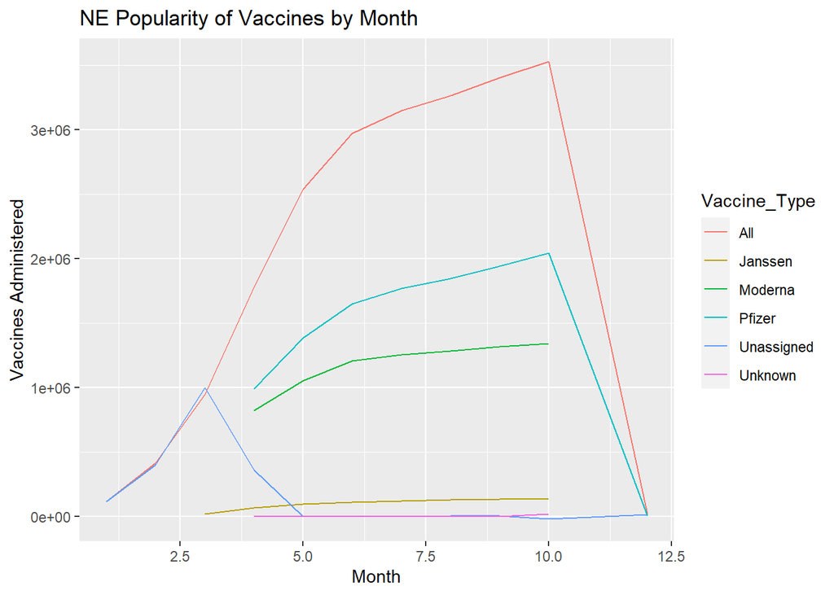

```r
library(lubridate)
df$Month = month(df$Date)
d3 <- df %>% filter(Province_State %in% c('Massachusetts','Rhode Island','Connecticut','Vermont','New Hampshire','Maine')) %>% group_by(Month, Vaccine_Type) %>% summarise(vac1_admin=mean(Doses_admin, na.rm = TRUE))
d3 %>% ggplot()+geom_line(mapping=aes(x=Month, y=vac1_admin, color=Vaccine_Type)) + labs(title = 'NE Popularity of Vaccines by Month', x = 'Month', y = 'Vaccines Administered')
```

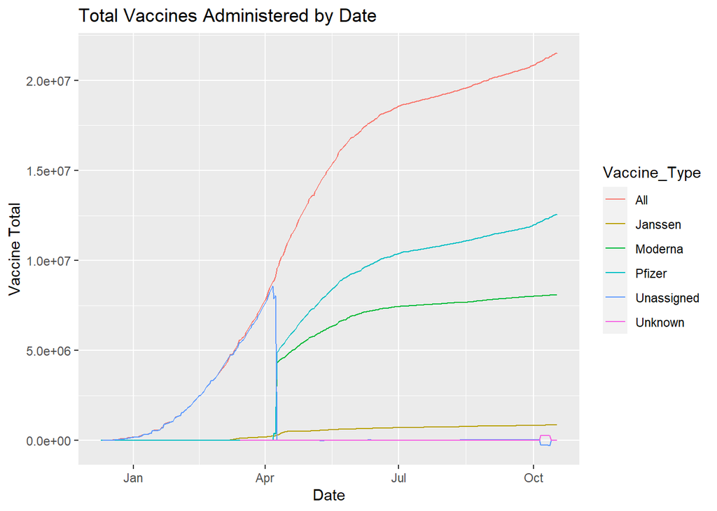

```r
d4 <- df %>% filter(Province_State %in% c('Massachusetts','Rhode Island','Connecticut','Vermont','New Hampshire','Maine')) %>% group_by(Date, Vaccine_Type) %>% summarise(vac_total=sum(Doses_admin, na.rm = TRUE))
d4 %>% ggplot()+geom_line(mapping=aes(x=Date, y=vac_total, color=Vaccine_Type)) + labs(title = 'Total Vaccines Administered by Date', x = 'Date', y = 'Vaccine Total')
```

2. Since the data seems lack of categorical variables, we will create a few categorical variables for easier visualization. From the `Date` variable create three categorical variables to record weekdays, months and quarters. You could also create a categorical variable to record the state regions (South, North East, Midwest, West) or other new categorical variables.

```r
library(lubridate)
df$Month = month(df$Date)
df$Weekday = wday(df$Date)
df$Quarter = quarter(df$Date)
```

3. With the updated data after question 2. Create at least 7 new meaningful graphs. Your graphs should have titles, captions, appropriate labels on x and y-axis. You should also make use of the follows.
- geom_point

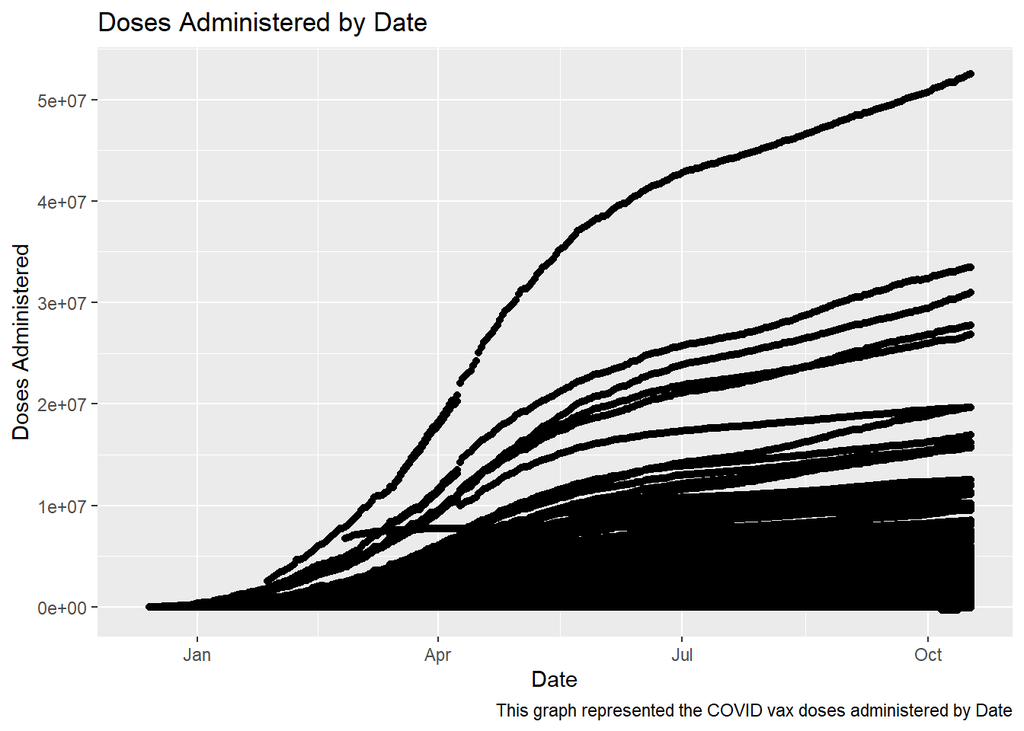

```r
df %>% ggplot() + geom_point(mapping=aes(x=Date, y=Doses_admin)) + labs(title = 'Doses Administered by Date', caption = 'This graph represented the COVID vax doses administered by Date', x = 'Date', y = 'Doses Administered')
```

- geom_line

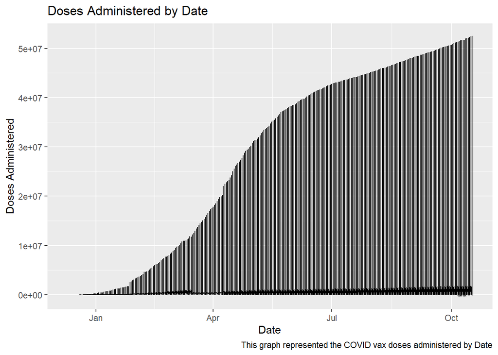

```r
df %>% ggplot() + geom_line(mapping=aes(x=Date, y=Doses_admin)) + labs(title = 'Doses Administered by Date', caption = 'This graph represented the COVID vax doses administered by Date', x = 'Date', y = 'Doses Administered')
```

- geom_smooth

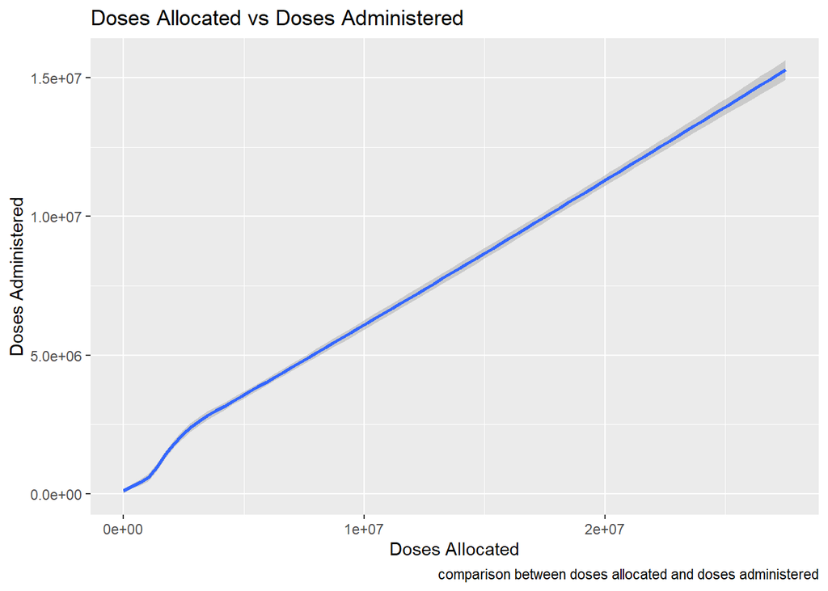

```r
df %>% ggplot() + geom_smooth(mapping=aes(x=Doses_alloc, y=Doses_admin)) + labs(title = 'Doses Allocated vs Doses Administered', caption = 'comparison between doses allocated and doses administered', x = 'Doses Allocated', y = 'Doses Administered')
```

_ geom_bar